# Analisis de Correspondencias

Mauricio Garcia Tec

2017-03-28

```r
library(metodosMultivariados2017)
library(datasets)
library(knitr)
```

```r
data("HairEyeColor")
tbl <- apply(HairEyeColor, c(1,2), sum)
dimnames(tbl) <- list(paste(dimnames(tbl)[[1]], "Hair"),
                      paste(dimnames(tbl)[[2]], "Eyes"))
kable(tbl)
```

|  | Brown Eyes | Blue Eyes | Hazel Eyes | Green Eyes |
| --- | --- | --- | --- | --- |
| Black Hair | 68 | 20 | 15 | 5 |
| Brown Hair | 119 | 84 | 54 | 29 |
| Red Hair | 26 | 17 | 14 | 14 |
| Blond Hair | 7 | 94 | 10 | 16 |

```r
X <- contingency_dummies(tbl)[[1]]
Y <- contingency_dummies(tbl)[[2]]
```

```r
kable(head(X))
```

| Black Hair | Brown Hair | Red Hair | Blond Hair |
| --- | --- | --- | --- |
| TRUE | FALSE | FALSE | FALSE |
| TRUE | FALSE | FALSE | FALSE |
| TRUE | FALSE | FALSE | FALSE |
| TRUE | FALSE | FALSE | FALSE |
| TRUE | FALSE | FALSE | FALSE |
| TRUE | FALSE | FALSE | FALSE |

```r
kable(tail(Y))
```

|  | Brown Eyes | Blue Eyes | Hazel Eyes | Green Eyes |
| --- | --- | --- | --- | --- |
| [587,] | FALSE | FALSE | FALSE | TRUE |
| [588,] | FALSE | FALSE | FALSE | TRUE |
| [589,] | FALSE | FALSE | FALSE | TRUE |
| [590,] | FALSE | FALSE | FALSE | TRUE |
| [591,] | FALSE | FALSE | FALSE | TRUE |
| [592,] | FALSE | FALSE | FALSE | TRUE |

### Calculos

Recuperar la tabla de contingencia

```r
kable(t(X) %*% Y)
```

|  | Brown Eyes | Blue Eyes | Hazel Eyes | Green Eyes |
| --- | --- | --- | --- | --- |
| Black Hair | 68 | 20 | 15 | 5 |
| Brown Hair | 119 | 84 | 54 | 29 |
| Red Hair | 26 | 17 | 14 | 14 |
| Blond Hair | 7 | 94 | 10 | 16 |

Total de observaciones en X

```r
kable(t(X) %*% X)
```

|  | Black Hair | Brown Hair | Red Hair | Blond Hair |
| --- | --- | --- | --- | --- |
| Black Hair | 108 | 0 | 0 | 0 |
| Brown Hair | 0 | 286 | 0 | 0 |
| Red Hair | 0 | 0 | 71 | 0 |
| Blond Hair | 0 | 0 | 0 | 127 |

Total de observaciones en Y

```r
kable(t(Y) %*% Y)
```

|  | Brown Eyes | Blue Eyes | Hazel Eyes | Green Eyes |
| --- | --- | --- | --- | --- |
| Brown Eyes | 220 | 0 | 0 | 0 |
| Blue Eyes | 0 | 215 | 0 | 0 |
| Hazel Eyes | 0 | 0 | 93 | 0 |
| Green Eyes | 0 | 0 | 0 | 64 |

Matriz de frecuencias relativas

```r
kable(t(X) %*% Y / sum(as.numeric(t(X) %*% Y)))
```

|  | Brown Eyes | Blue Eyes | Hazel Eyes | Green Eyes |
| --- | --- | --- | --- | --- |
| Black Hair | 0.1148649 | 0.0337838 | 0.0253378 | 0.0084459 |
| Brown Hair | 0.2010135 | 0.1418919 | 0.0912162 | 0.0489865 |
| Red Hair | 0.0439189 | 0.0287162 | 0.0236486 | 0.0236486 |
| Blond Hair | 0.0118243 | 0.1587838 | 0.0168919 | 0.0270270 |

Otra forma de construirla matricialmente

```r
ones_row <- rep(1, ncol(X))
ones_col <- rep(1, ncol(Y))
N <- as.numeric(ones_row %*% t(X) %*% Y %*% ones_col)
P <- t(X) %*% Y / N
kable(P)
```

|  | Brown Eyes | Blue Eyes | Hazel Eyes | Green Eyes |
| --- | --- | --- | --- | --- |
| Black Hair | 0.1148649 | 0.0337838 | 0.0253378 | 0.0084459 |
| Brown Hair | 0.2010135 | 0.1418919 | 0.0912162 | 0.0489865 |
| Red Hair | 0.0439189 | 0.0287162 | 0.0236486 | 0.0236486 |
| Blond Hair | 0.0118243 | 0.1587838 | 0.0168919 | 0.0270270 |

### Analisis por filas

Vamos a construir la matriz de perfiles por fila. Consiste del conteo en cada celda dividiendo cada fila por la suma de la fila. Recordemos que las suma de las filas se obtienen de la diagonal de $X^tX$.

Ademas reconocemos la estructura conocida de
$$(X^tX)^{-1}X^tY$$
. La entrada $(r,c)$ representa $P(Y=c|X=r)$.

```r
# (X'X)^(-1)X'Y
Pr <- solve(t(X) %*% X, t(X) %*% Y)
kable(Pr)
```

|  | Brown Eyes | Blue Eyes | Hazel Eyes | Green Eyes |
| --- | --- | --- | --- | --- |
| Black Hair | 0.6296296 | 0.1851852 | 0.1388889 | 0.0462963 |
| Brown Hair | 0.4160839 | 0.2937063 | 0.1888112 | 0.1013986 |
| Red Hair | 0.3661972 | 0.2394366 | 0.1971831 | 0.1971831 |
| Blond Hair | 0.0551181 | 0.7401575 | 0.0787402 | 0.1259843 |

Visualizamos

```r
library(ggtern)
```

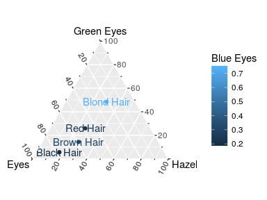

```r
plot_dat <- data.frame(Pr, check.names = FALSE)
ggtern(plot_dat, aes(x = `Brown Eyes`,
               y = `Green Eyes`,
               z = `Hazel Eyes`,
                colour = `Blue Eyes`)) +
  geom_point() +
  geom_text(aes(label = row.names(plot_dat)))
```

Para poder medir distancias adecuadamente entre cada perfil de fila, necesitamos medir la diferencia en distribución pesada inversamente proporcional al peso o masa de cada columna. Esto se conoce como distancia **chi-cuadrada**.

```r
chi_dist <-  function(row1, row2, tbl) {
  col_masses <-  as.numeric(apply(tbl, 2, sum)) /
    sum(as.numeric(tbl))
  Pr <- solve(t(X) %*% X, t(X) %*% Y)
  dif <- as.numeric(Pr[row1, ]) - as.numeric(Pr[row2, ])
  sqrt(sum((1 / col_masses)*dif^2))
}
```

```r
col_mass <- apply(tbl, 2, sum) /
  sum(as.numeric(tbl))
kable(col_mass)
```

| Brown Eyes | 0.3716216 |
| --- | --- |
| Blue Eyes | 0.3631757 |
| Hazel Eyes | 0.1570946 |
| Green Eyes | 0.1081081 |

Por ejemplo, distancia entre brown hair y black hair es

```r
chi_dist(1, 2, tbl)
```

```
## [1] 0.4461923
```

```r
chi_dist(1, 4, tbl)
```

```
## [1] 1.348332
```

Matriz de distancia entre perfiles de fila

```r
hair_types <- dimnames(tbl)[[1]]
n_types <- length(hair_types)
row_dist_mat <- matrix(0,
                       ncol = n_types,
                       nrow = n_types,
                       dimnames = list(hair_types, hair_types))
for (i in 1:(n_types - 1)) {
  for (j in i:n_types) {
    row_dist_mat[i, j] <- chi_dist(i, j, tbl)
    row_dist_mat[j, i] <-  row_dist_mat[i, j]
  }
}
kable(row_dist_mat)
```

|  | Black Hair | Brown Hair | Red Hair | Blond Hair |
| --- | --- | --- | --- | --- |
| Black Hair | 0.0000000 | 0.4461923 | 0.6535052 | 1.3483317 |
| Brown Hair | 0.4461923 | 0.0000000 | 0.3164147 | 0.9910356 |
| Red Hair | 0.6535052 | 0.3164147 | 0.0000000 | 1.0425690 |
| Blond Hair | 1.3483317 | 0.9910356 | 1.0425690 | 0.0000000 |

## Scores o factores de filas

Tenemos que hacer una descomposicion de valores singulares generalizada como sigue.

Primero vamos a voltear a ver la matriz de diferencias respecto al “tipo de ojo esperado del total de la poblacion del mundo”.

```r
col_mass <- apply(tbl, 2, sum) /
  sum(as.numeric(tbl))
kable(col_mass)
```

| Brown Eyes | 0.3716216 |
| --- | --- |
| Blue Eyes | 0.3631757 |
| Hazel Eyes | 0.1570946 |
| Green Eyes | 0.1081081 |

Vamos a calcular las diferencias respecto a perfil del “mundo”

```r
 # restar a cada columna su masa (el porcentaje obsevado de ese color de ojos)
Pr_tilde <- Pr - ones_col %*% t(col_mass)
kable(Pr_tilde)
```

[output not shown]

```r
kable(ones_col %*% t(col_mass))
```

| Brown Eyes | Blue Eyes | Hazel Eyes | Green Eyes |
| --- | --- | --- | --- |
| 0.3716216 | 0.3631757 | 0.1570946 | 0.1081081 |
| 0.3716216 | 0.3631757 | 0.1570946 | 0.1081081 |
| 0.3716216 | 0.3631757 | 0.1570946 | 0.1081081 |
| 0.3716216 | 0.3631757 | 0.1570946 | 0.1081081 |

```r
apply(tbl, 2, sum) / sum(as.numeric(tbl))
```

```
## Brown Eyes  Blue Eyes Hazel Eyes Green Eyes
##  0.3716216  0.3631757  0.1570946  0.1081081
```

## Scores de filas

```r
n <- sum(as.numeric(tbl))
P <- tbl/n
row_mass <- as.numeric(apply(P, 1, sum))
col_mass <- as.numeric(apply(P, 2, sum))
Dr <- diag(row_mass)
Dc <- diag(col_mass)
RowProfile <- solve(Dr, P)
RowProfileC <- RowProfile
for (i in 1:nrow(RowProfile))
  RowProfileC[i, ] <- RowProfileC[i, ] -col_mass
covR <- RowProfileC %*% solve(Dc) %*% t(RowProfileC)
res <- eigen(covR)
row_factor1 <- res$vectors[ ,1] * sqrt(res$values[1])
row_factor2 <- res$vectors[ ,2] * sqrt(res$values[2])
row_names <- dimnames(tbl)[[1]]
```

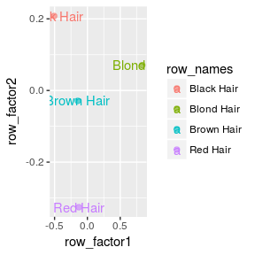

```r
data <- data.frame(row_factor1,
                   row_factor2,
                   row_names)
ggplot(data, aes(x = row_factor1, y= row_factor2, colour = row_names)) +
  geom_point(size = 2, alpha = 0.6) +
  geom_text(aes(x = row_factor1, y= row_factor2, label = row_names))
```

```r
# varianza explicada
var_exp <- cumsum(res$values) / sum(res$values)
scales::percent(var_exp)
```

```
## [1] "85.6%"  "99.0%"  "100.0%" "100.0%"
```

## Scores de columnas

```r
ColProfile <- P %*% solve(Dc)
ColProfileC <- ColProfile
for (j in 1:ncol(ColProfileC))
  ColProfileC[ ,j] <- ColProfileC[ ,j] - row_mass
covC <- t(ColProfileC) %*% solve(Dr) %*% ColProfileC
res <- eigen(covC)
col_factor1 <- res$vectors[ ,1] * sqrt(res$values[1])
col_factor2 <- res$vectors[ ,2] * sqrt(res$values[2])
col_names <- dimnames(tbl)[[2]]
```

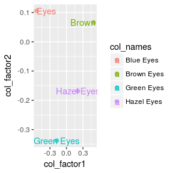

```r
data <- data.frame(col_factor1,
                   col_factor2,
                   col_names)
ggplot(data, aes(x = col_factor1, y= col_factor2, colour = col_names)) +
  geom_point(size = 2, alpha = 0.6) +
  geom_text(aes(x = col_factor1, y= col_factor2, label = col_names))
```

# Pintamos juntos

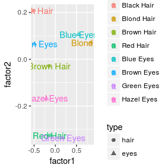

```r
data_row <- data.frame(factor1 = row_factor1,
                   factor2 = row_factor2,
                   variable = row_names, type = "hair")
data_col <- data.frame(factor1 = - col_factor1,
                   factor2 = col_factor2,
                   variable = col_names, type = "eyes")
data_all <- rbind(data_row, data_col)

ggplot(data_all, aes(x = factor1, y= factor2, colour = variable, shape = type)) +
  geom_point(size = 2, alpha = 0.6) +
  geom_text(aes(x = factor1, y= factor2, label = variable))
```